# Niger Anticipatory Action: Drought

IRI Forecast-Based Trigger Design · 1998–2025

Published

19 May 2026

DRAFT — NOT FOR DISTRIBUTION

## Overview

This document describes the design of an anticipatory action trigger for drought in Niger, based on IRI seasonal forecast probabilities and an August rainfall observation.

The trigger has **two independent arms** — either can fire to release early action:

- **Forecast arm**: fires when any two consecutive monthly IRI forecasts (January–June) are both in the top 3 years per month in the detrended historical record. This results in **5 total forecast-arm trigger years** out of 28.
- **Observation arm**: fires when early August rainfall is among the bottom 5 driest years, covering **5 observation-arm trigger years**.

The forecast and observation arms are designed to each fire in **5 years**, giving them equal probability of triggering. This represents a deliberate design choice: an earlier version of this framework used a much wider observation arm (proportionally far more observation-arm trigger years than forecast-arm years), meaning the trigger was far more likely to fire on the observation arm than the forecast arm. The revised design balances the two arms, preserving the value of the early warning signal from the forecast arm.

## Data

Three data sources are used:

| Variable | Description | Period |
| --- | --- | --- |
| IRI Jan–Jun | Monthly probability of below-normal JAS precipitation (%) | 1991–2025 |
| Aug observation | August rainfall z-score (CHIRPS-based) | 1998–2025 |
| JAS SPI | July–August–September SPI (validation outcome) | 1998–2024 |

The IRI forecast probabilities are expressed as fractions (0–1) of the climatological below-normal tercile. The August observation is a standardised anomaly — lower (more negative) values indicate drier conditions.

The beta regression trend models are **fit on the full 1991–2025 record** to maximise sample size for estimating the long-term climate shift. The trigger threshold design uses **1998–2025 only**, matching the period of reliable operational data.

## Detrending

IRI seasonal forecast probabilities for below-normal precipitation show a declining trend over 1991–2025. This likely reflects the partial recovery of Sahelian rainfall since the 1970s–80s drought era, alongside improvements in the IRI model’s baseline climatology. Without detrending, a historical percentile threshold would systematically favour recent years and underweight older drought signals.

We apply a two-step detrending procedure:

1. **Beta regression** — fits a trend curve bounded to (0, 1), appropriate for probability data. Divides out the trend so the series fluctuates around a constant mean.
2. **Variance standardisation** — fits a linear model to the absolute residuals over time, then rescales so the spread is constant across years.

The beta trend is fit on the **full historical record** (1991–2025); the variance model is also fit on all years. Both are then applied to the 1998–2025 analysis window.

### Detrending steps

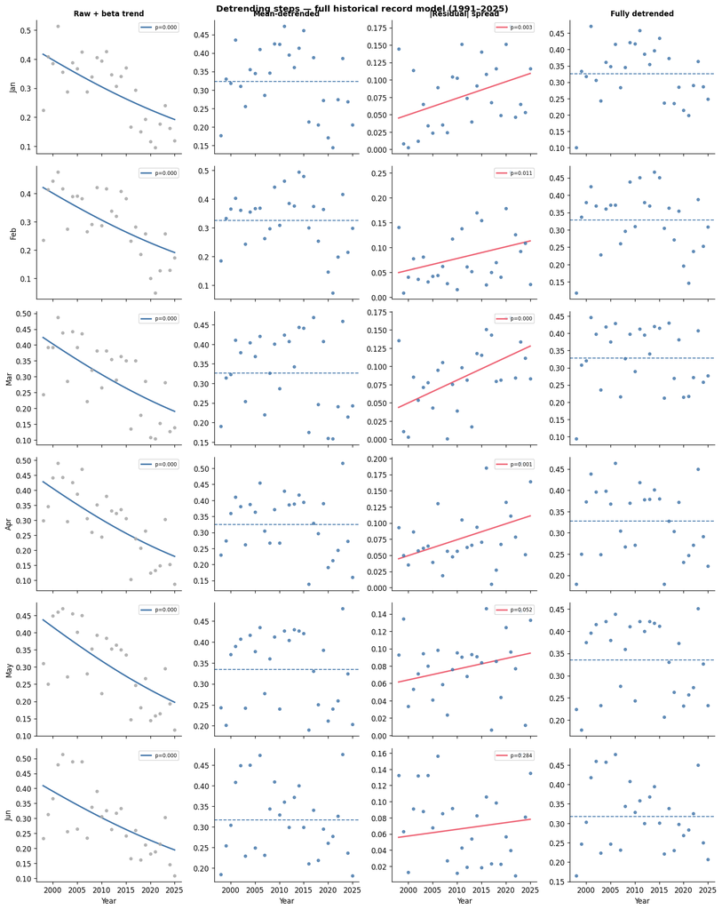

### Model fit summary

Table 1: Beta trend and variance fit quality. β R²: Pearson r² between fitted trend and squeezed observations. Var R²: r² of linear fit on |residual| vs year.

| Month | β coef | β p | β R² | Var R² | Var p |
| --- | --- | --- | --- | --- | --- |
| Jan | -0.0407 | 0.000 | 0.579 | 0.244 | 0.003 |
| Feb | -0.0416 | 0.000 | 0.550 | 0.180 | 0.011 |
| Mar | -0.0422 | 0.000 | 0.590 | 0.421 | 0.000 |
| Apr | -0.0455 | 0.000 | 0.663 | 0.283 | 0.001 |
| May | -0.0426 | 0.000 | 0.605 | 0.110 | 0.052 |
| Jun | -0.0390 | 0.000 | 0.572 | 0.035 | 0.284 |

A negative β coefficient indicates a declining trend in the below-normal forecast probability over time (fewer forecasts suggesting drought). The variance R² measures how much of the spread heteroscedasticity is explained by a linear trend in time.

## Forecast Skill

### JAS SPI timeseries

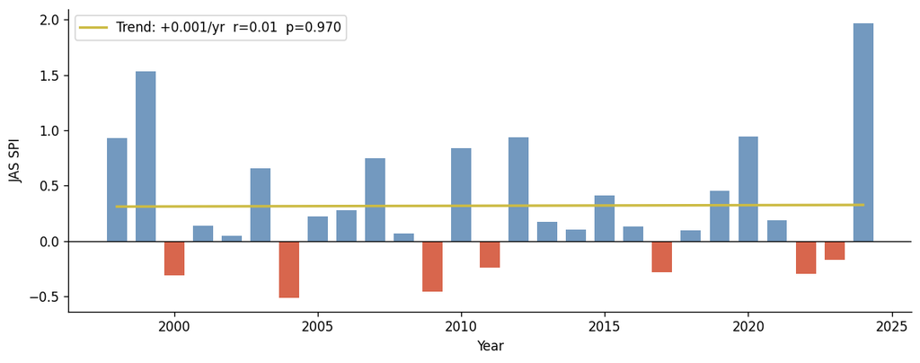

Figure 2: JAS SPI (July–August–September Standardised Precipitation Index), 1998–2024. Negative (red) bars indicate below-normal seasonal rainfall.

### Correlation with IRI forecasts

The plot below compares how strongly each monthly IRI forecast correlates with the JAS SPI outcome, before and after detrending. Negative correlations (plotted here as positive for readability) indicate that a higher “below-normal” forecast probability is associated with a drier season — a useful predictive signal.

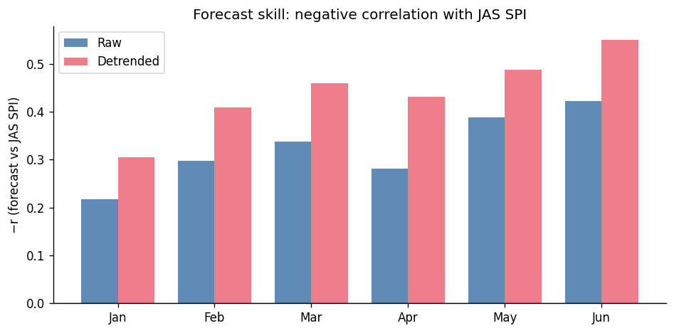

### ROC AUC — lower-tercile drought years

The ROC AUC summarises how well each monthly forecast discriminates between drought years (JAS SPI below the lower tercile) and non-drought years. An AUC of 0.5 is no better than chance; 1.0 is perfect.

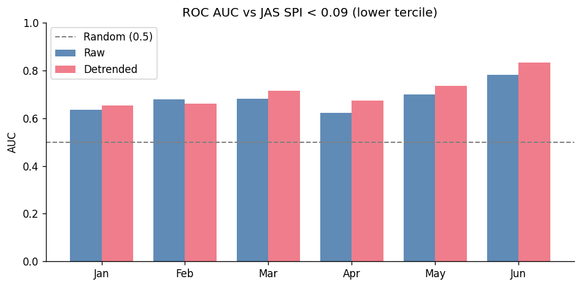

Figure 4: ROC AUC for each monthly IRI forecast against the binary outcome (JAS SPI below lower tercile). Values above 0.5 indicate useful forecast skill.

## Trigger Design

### Parameters

The trigger was designed over 28 years (1998–2025) using the **full historical record detrending model**. The selected thresholds fire in approximately 8 out of 28 years — a **1-in-3.6** combined return period.

| Parameter | Value |
| --- | --- |
| Analysis period | 1998–2025 (28 years) |
| Detrending model | Full historical record (1991–2025) |
| Forecast arm: threshold per month | Top 3 of 28 years per month |
| Forecast arm: total trigger years | 5 / 28 ≈ 17.9% |
| Observation arm: trigger years | Bottom 5 of 28 ≈ 17.9% |
| Total trigger years | 8 / 28 |
| Combined return period | ~1-in-3.6 years |

The **observation arm** provides a safety net: it fires independently when the August rainfall observation is among the bottom 5 years, even if the forecast arm did not fire. Setting 5 = 5 gives both arms **equal trigger probability**, balancing the system so it is no more likely to release via observation than via forecast.

### Trigger arm comparison

The scatter below shows each historical year as a point. The x-axis is the August observation value (obs arm metric — lower is drier); the y-axis is the strongest consecutive forecast pair in that year, measured as the minimum of the two months’ detrended values (forecast arm metric — higher means both months were elevated). Threshold lines mark where each arm fires. Points are coloured by which arm(s) triggered.

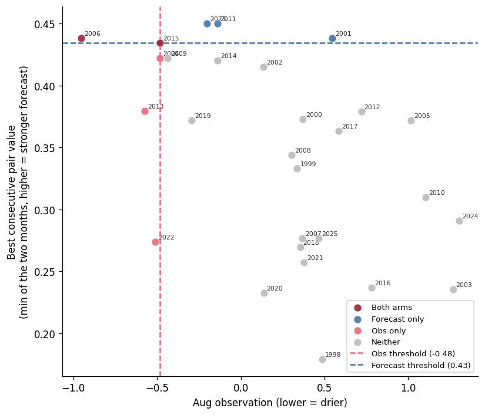

Figure 5: Each year plotted by its forecast-arm strength (y: max consecutive pair, min of the two months) vs its observation-arm value (x: Aug). Dashed lines mark the trigger thresholds. Colour shows which arm(s) fired.

### Forecast vs observation arm trade-off

The chart below shows the full design space: each point is a combination of total forecast-arm trigger years (x) and observation-arm trigger years (y), coloured by the resulting combined return period. Points on the 45° line have equal trigger probability for both arms.

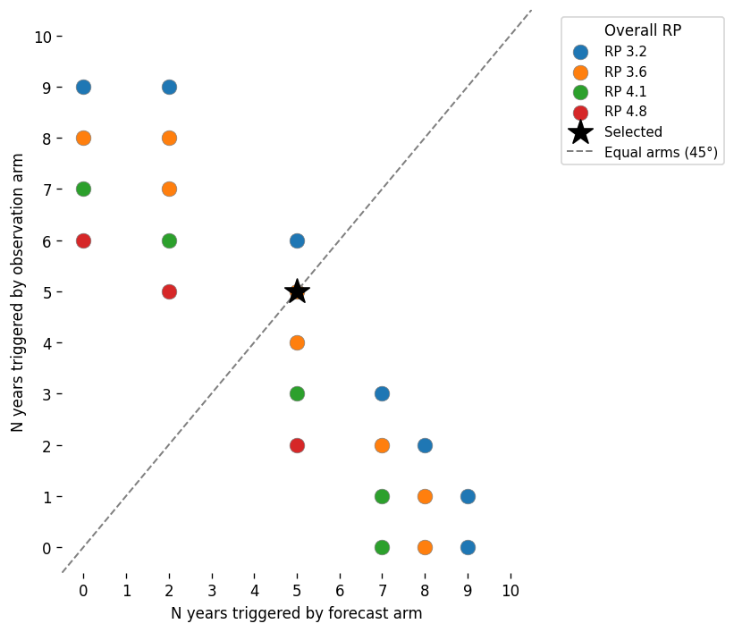

Figure 6: Forecast arm trigger years vs observation arm trigger years. Points are coloured by combined return period. The 45° dashed line marks equal probability for both arms; the star marks the selected design.

### Thresholds (detrended space)

Table 2: Trigger thresholds in fully detrended space. The August threshold applies to the observation arm.

| Month | Direction | Threshold | Percentile |
| --- | --- | --- | --- |
| Jan | ≥ (above) | 0.4344 | top 10.7% |
| Feb | ≥ (above) | 0.4504 | top 10.7% |
| Mar | ≥ (above) | 0.4292 | top 10.7% |
| Apr | ≥ (above) | 0.4384 | top 10.7% |
| May | ≥ (above) | 0.4225 | top 10.7% |
| Jun | ≥ (above) | 0.4571 | top 10.7% |
| Aug (obs) | ≤ (below) | -0.4830 | bottom 17.9% |

### Historical trigger years (1998–2025)

The table below shows which years triggered each arm. A year in the “either” column means early action would have been released.

| Year | Jan | Feb | Mar | Apr | May | Jun | Jan+Feb | Feb+Mar | Mar+Apr | Apr+May | May+Jun |
| --- | --- | --- | --- | --- | --- | --- | --- | --- | --- | --- | --- |
| 2025 | False | False | False | False | False | False | False | False | False | False | False |
| 2024 | False | False | False | False | False | False | False | False | False | False | False |
| 2023 | False | False | False | True | True | False | False | False | False | True | False |
| 2022 | False | False | False | False | False | False | False | False | False | False | False |
| 2021 | False | False | False | False | False | False | False | False | False | False | False |
| 2020 | False | False | False | False | False | False | False | False | False | False | False |
| 2019 | False | False | False | False | False | False | False | False | False | False | False |
| 2018 | False | False | False | False | False | False | False | False | False | False | False |
| 2017 | False | False | True | False | False | False | False | False | False | False | False |
| 2016 | False | False | False | False | False | False | False | False | False | False | False |
| 2015 | True | True | False | False | False | False | True | False | False | False | False |
| 2014 | False | True | False | False | False | False | False | False | False | False | False |
| 2013 | False | False | False | False | False | False | False | False | False | False | False |
| 2012 | False | False | False | False | False | False | False | False | False | False | False |
| 2011 | True | True | False | False | True | False | True | False | False | False | False |
| 2010 | False | False | False | False | False | False | False | False | False | False | False |
| 2009 | False | False | False | False | False | False | False | False | False | False | False |
| 2008 | False | False | False | False | False | False | False | False | False | False | False |
| 2007 | False | False | False | False | False | False | False | False | False | False | False |
| 2006 | False | False | True | True | True | True | False | False | True | True | True |
| 2005 | False | False | False | False | False | False | False | False | False | False | False |
| 2004 | False | False | False | False | False | True | False | False | False | False | False |
| 2003 | False | False | False | False | False | False | False | False | False | False | False |
| 2002 | False | False | False | False | False | True | False | False | False | False | False |
| 2001 | True | False | True | True | False | False | False | False | True | False | False |
| 2000 | False | False | False | False | False | False | False | False | False | False | False |
| 1999 | False | False | False | False | False | False | False | False | False | False | False |
| 1998 | False | False | False | False | False | False | False | False | False | False | False |

Table 4: Overall trigger summary by year.

| Year | Forecast arm | Observation arm | Either (trigger) |
| --- | --- | --- | --- |
| 2025 | False | False | False |
| 2024 | False | False | False |
| 2023 | True | False | True |
| 2022 | False | True | True |
| 2021 | False | False | False |
| 2020 | False | False | False |
| 2019 | False | False | False |
| 2018 | False | False | False |
| 2017 | False | False | False |
| 2016 | False | False | False |
| 2015 | True | True | True |
| 2014 | False | False | False |
| 2013 | False | True | True |
| 2012 | False | False | False |
| 2011 | True | False | True |
| 2010 | False | False | False |
| 2009 | False | False | False |
| 2008 | False | False | False |
| 2007 | False | False | False |
| 2006 | True | True | True |
| 2005 | False | False | False |
| 2004 | False | True | True |
| 2003 | False | False | False |
| 2002 | False | False | False |
| 2001 | True | False | True |
| 2000 | False | False | False |
| 1999 | False | False | False |
| 1998 | False | False | False |

## Back-Transformed Thresholds

The thresholds above are defined in **detrended space** — a stationary series where the declining trend has been removed. To apply the trigger in practice, we need the equivalent threshold in **raw forecast probability space** for each future year.

The back-transformation inverts both detrending steps using the fitted models, accounting for the expected beta trend and spread at each year. Because the underlying trend in below-normal probabilities is declining, the raw threshold for 2026–2027 is **lower** than it would have been in the 1990s — the trigger will fire at a lower absolute forecast probability, reflecting the changed climatology.

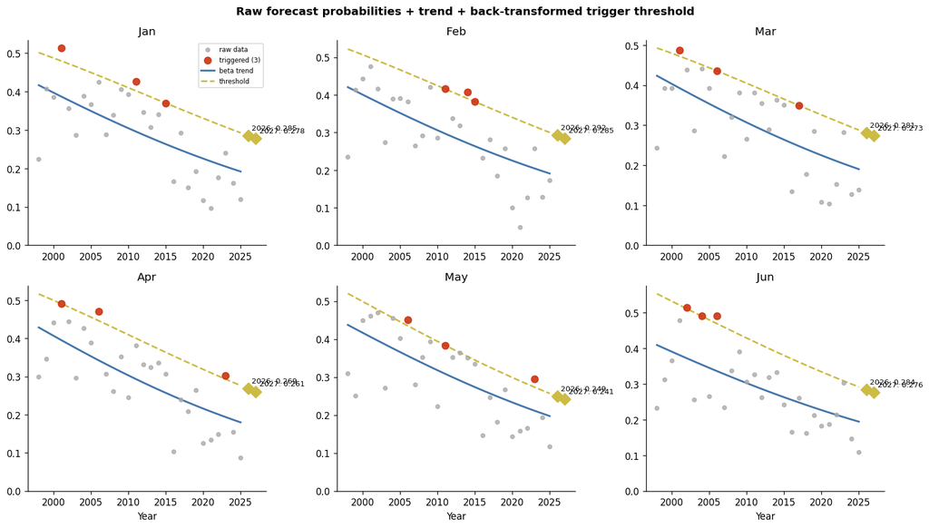

Figure 7: Raw IRI forecast probabilities (grey) with beta trend (blue) and back-transformed trigger threshold (gold dashed). Red dots mark years that triggered in detrended space. Gold diamonds show the 2026 and 2027 threshold values.

### Forward-looking thresholds

The table below gives the trigger threshold in raw forecast probability space for 2026 and 2027. A monthly IRI below-normal probability **at or above** the value shown means that month contributes toward triggering the forecast arm (subject to the consecutive-month requirement).

Table 5: Back-transformed trigger thresholds for 2026 and 2027. Values are the minimum below-normal probability needed for a month to count toward the forecast arm trigger.

| Month | Detrended thresh | 2026 | 2027 |
| --- | --- | --- | --- |
| Jan | 0.4344 | 28.5% | 27.8% |
| Feb | 0.4504 | 29.2% | 28.5% |
| Mar | 0.4292 | 28.1% | 27.3% |
| Apr | 0.4384 | 26.9% | 26.1% |
| May | 0.4225 | 24.9% | 24.1% |
| Jun | 0.4571 | 28.4% | 27.6% |

These thresholds are lower than they would have been a decade ago, reflecting the declining climatological trend. The trigger is designed to remain calibrated to a consistent return period as the climate context evolves.